# Verzani Problem Set

### Problem 4.3

The built-in data set `mammals` contains data on body weight versus brain weight. Use the `cor` to find the Pearson and Spearman correlation coefficients. Are they similar?

```r
> cor(mammals$brain, mammals$body)
[1] 0.9341638
> cor(rank(mammals$brain), rank(mammals$body))
[1] 0.9534986
```

Plot the data using the `plot` command and see if you expect them to be similar.

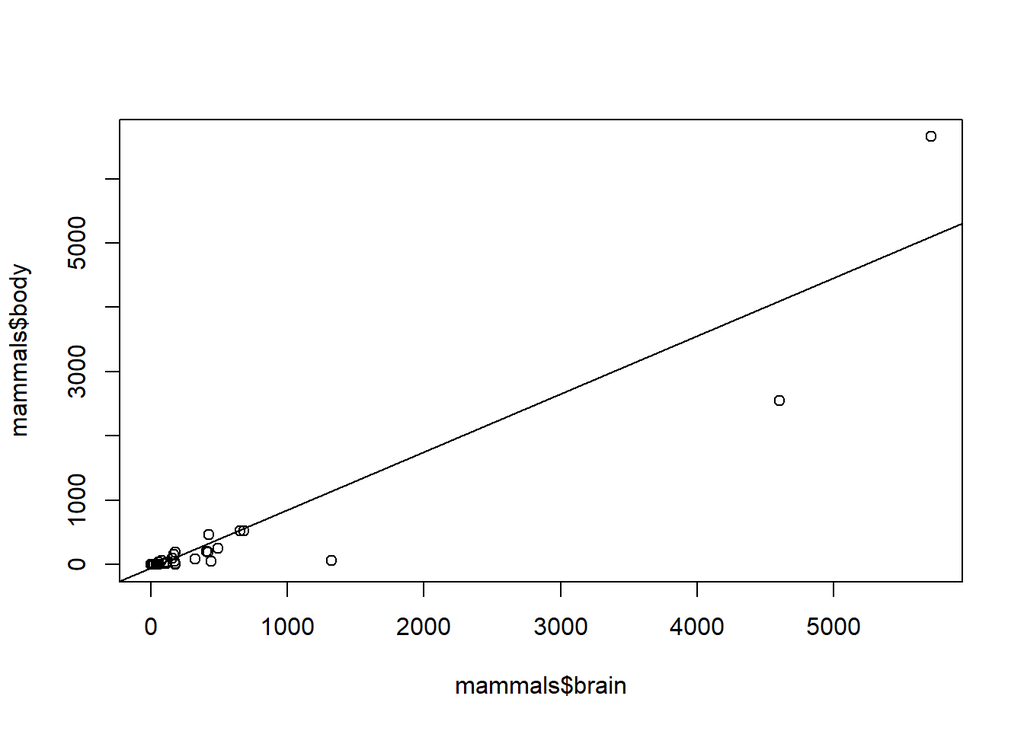

```r
> plot(mammals$brain, mammals$body)
> abline(lm(mammals$body~mammals$brain))
```

You should be unsatisfied with this plot. Next, plot the logarithm (`log`) of each variable and see if that makes a difference.

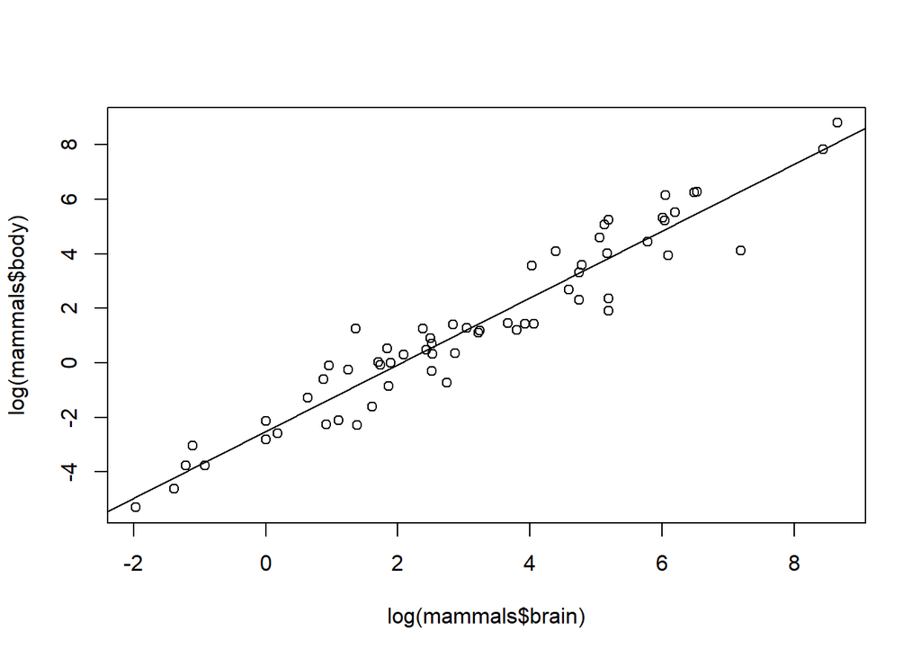

```r
> plot(log(mammals$brain), log(mammals$body))
> abline(lm(log(mammals$body) ~ log(mammals$brain)))
```